# Neural Network in R - Bank Customer Churn model

### Objective

To develop a model/method for identifying customers who are likely to exit

### Background:

Bank customer churn, also known as customer attrition, refers to the phenomenon where customers stop doing business with a bank or switch to another bank. Churn is a critical metric for banks as it directly impacts their customer base and revenue. The dataset represents bank customer information for churn analysis. Each row in the dataset corresponds to a specific customer and contains several features or attributes that describe them.  
While we have worked with BLR, Naive Bayes, SVM and Tree methods in earlier case studies, we will be using Artificial Neural Network method in this case study.

### Import libraries

```r
library(dplyr)
library(fastDummies)
library(neuralnet)
library(caret)
library(ROCR)
```

### Import data

```r
data <- read.csv('Bank Churn.csv')
head(data)
```

```
  RowNumber CustomerId  Surname CreditScore Geography Gender Age Tenure
1         1   15634602 Hargrave         619    France Female  42      2
2         2   15647311     Hill         608     Spain Female  41      1
3         3   15619304     Onio         502    France Female  42      8
4         4   15701354     Boni         699    France Female  39      1
5         5   15737888 Mitchell         850     Spain Female  43      2
6         6   15574012      Chu         645     Spain   Male  44      8
    Balance NumOfProducts HasCrCard IsActiveMember EstimatedSalary Exited
1      0.00             1         1              1       101348.88      1
2  83807.86             1         0              1       112542.58      0
3 159660.80             3         1              0       113931.57      1
4      0.00             2         0              0        93826.63      0
5 125510.82             1         1              1        79084.10      0
6 113755.78             2         1              0       149756.71      1
```

### Data description

| Field | Description |
| --- | --- |
| CustomerId | Customer identifiers |
| Surname | Surname of Customer |
| CreditScore | Creditworthiness score of customers |
| Geography | Country name |
| Gender | Gender of customer |
| Age | Age of customer |
| Tenure | Duration of customer engagement or membership |
| Balance | Amount of funds held in customer accounts |
| NumOfProducts | Number of products or services owned by customers |
| HasCrCard | Whether customers possess a credit card or not |
| IsActiveMember | Whether customers are active member of loyalty program |
| EstimatedSalary | The approximate salary of customers |
| Exited | Whether customers have churned or exited the service |

### Data pre-processing

- Creating dummy variables for categorical variables (conversion required to assign weights)
- Scaling the variables (a variable may have a large impact on the prediction variable only because of its scale)

```r
# Creating dummy variables
data <- dummy_cols(data,select_columns = c("Geography", "Gender"),remove_first_dummy = T)

# Scaling
normalize <- function(x) {
  return ((x - min(x)) / (max(x) - min(x)))
}

data$Age <- normalize(data$Age)
data$Tenure<- normalize(data$Tenure)
data$NumOfProducts <- normalize(data$NumOfProducts)
data$EstimatedSalary <- normalize(data$EstimatedSalary)
data$CreditScore <- normalize(data$CreditScore)
data$Balance <- normalize(data$Balance)
```

### Estimating the attrition rate

```r
counts  <-data.frame(table(data$Exited))
colnames(counts)[1] <- "Exited"
counts$Percent <- counts$Freq / sum(counts$Freq)
counts
```

```
  Exited Freq Percent
1      0 7963  0.7963
2      1 2037  0.2037
```

Attrition rate for customers is around 20%

### Splitting data into Train and Test data sets

```r
set.seed(20240612)
index <- createDataPartition(data$Exited, p=0.7, list= F)

traindata <- data[index,]
testdata <- data[-index,]
```

### Building model

“hidden=” argument is to specify the number of hidden neurons in each layer.

```r
nn_churn <- neuralnet(Exited ~ CreditScore + Geography_Germany + Geography_Spain + Gender_Male + Age + Tenure + Balance + NumOfProducts+ HasCrCard + IsActiveMember + EstimatedSalary,
                      data = traindata,
                      hidden = 2, err.fct="ce", linear.output=FALSE)

# appending probability estimates to independent variables
out_churn <- cbind(nn_churn$covariate,nn_churn$net.result[[1]])

# renaming variables
dimnames(out_churn) <- list(NULL, c("CreditScore","Geography_Germany","Geography_Spain","Gender_Male","Age","Tenure","Balance","NumOfProducts","HasCrCard","IsActiveMember","EstimatedSalary","nn_output"))
head(out_churn)
```

```
     CreditScore Geography_Germany Geography_Spain Gender_Male       Age Tenure
[1,]       1.000                 0               1           0 0.3378378    0.2
[2,]       0.590                 0               1           1 0.3513514    0.8
[3,]       0.944                 0               0           1 0.4324324    0.7
[4,]       0.052                 1               0           0 0.1486486    0.4
[5,]       0.302                 0               0           1 0.3513514    0.4
[6,]       0.668                 0               0           1 0.1216216    0.2
       Balance NumOfProducts HasCrCard IsActiveMember EstimatedSalary
[1,] 0.5002462     0.0000000         1              1       0.3954004
[2,] 0.4533944     0.3333333         1              0       0.7487972
[3,] 0.0000000     0.3333333         1              1       0.0502609
[4,] 0.4585397     1.0000000         1              0       0.5967335
[5,] 0.5661704     0.3333333         0              1       0.3746804
[6,] 0.5364883     0.0000000         1              1       0.3586050
      nn_output
[1,] 0.13379941
[2,] 0.18762400
[3,] 0.02255485
[4,] 0.99997441
[5,] 0.11233128
[6,] 0.03022403
```

### Neural network plot

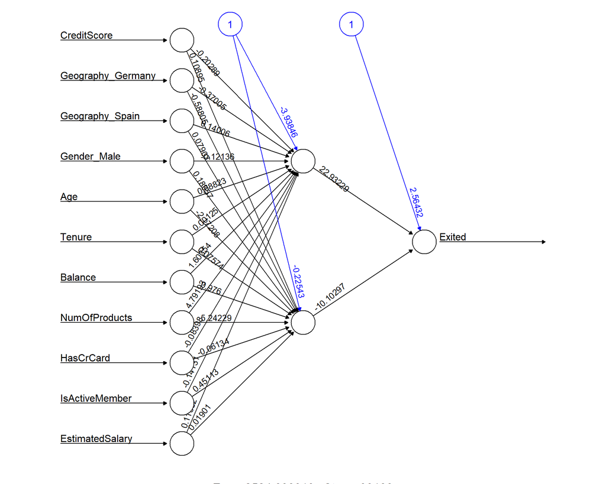

```r
plot(nn_churn, rep = "best")
```

#### ROC Curve and AUC for Train Data

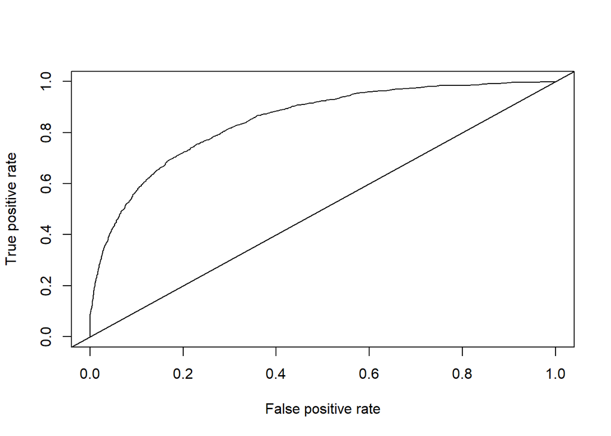

```r
# Convert 'out' to dataframe
outdf<-as.data.frame(out_churn)
pred <- prediction(outdf$nn_output, traindata$Exited)
perf<-performance(pred,"tpr","fpr")
plot(perf)
abline(0,1)
```

```r
auc<-performance(pred,"auc")
auc@y.values
```

```
[[1]]
[1] 0.8465933
```

### Confusion Matrix for train data

```r
# Predicted Y for train data
traindata$predY<-as.factor(ifelse(outdf$nn_output > 0.5 ,1,0))

#Train data confusion Matrix
confusionMatrix(as.factor(traindata$predY), as.factor(traindata$Exited), positive="1")
```

```
Confusion Matrix and Statistics

          Reference
Prediction    0    1
         0 5326  839
         1  249  586

               Accuracy : 0.8446
                 95% CI : (0.8359, 0.853)
    No Information Rate : 0.7964
    P-Value [Acc > NIR] : < 2.2e-16

                  Kappa : 0.4333

 Mcnemar's Test P-Value : < 2.2e-16

            Sensitivity : 0.41123
            Specificity : 0.95534
         Pos Pred Value : 0.70180
         Neg Pred Value : 0.86391
             Prevalence : 0.20357
         Detection Rate : 0.08371
   Detection Prevalence : 0.11929
      Balanced Accuracy : 0.68328

       'Positive' Class : 1
```

#### Comment :

The overall model accuracy is 84%. The area under ROC curve is 84.66

### ROC Curve and AUC for test data

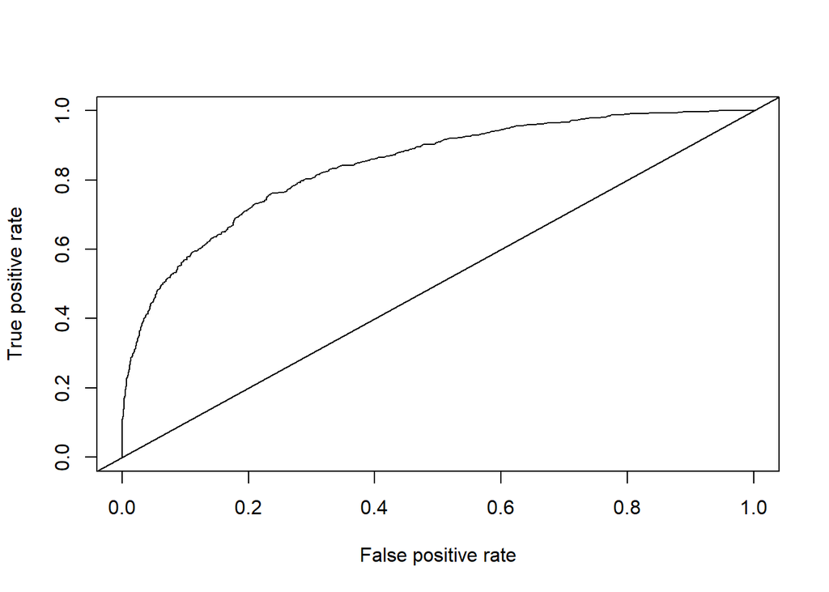

```r
prednn <- predict(nn_churn ,testdata)

pred<-prediction(prednn,testdata$Exited)
perf<-performance(pred,"tpr","fpr")
plot(perf)
abline(0,1)
```

```r
auc<-performance(pred,"auc")
auc@y.values
```

```
[[1]]
[1] 0.8411468
```

#### Confusion Matrix for test data

```r
# Predicted Y for train data
testdata$predY<-as.factor(ifelse(prednn > 0.5 ,1,0))

#Train data confusion Matrix
confusionMatrix(as.factor(testdata$predY), as.factor(testdata$Exited), positive="1")
```

```
Confusion Matrix and Statistics

          Reference
Prediction    0    1
         0 2271  336
         1  117  276

               Accuracy : 0.849
                 95% CI : (0.8357, 0.8616)
    No Information Rate : 0.796
    P-Value [Acc > NIR] : 5.015e-14

                  Kappa : 0.4637

 Mcnemar's Test P-Value : < 2.2e-16

            Sensitivity : 0.4510
            Specificity : 0.9510
         Pos Pred Value : 0.7023
         Neg Pred Value : 0.8711
             Prevalence : 0.2040
         Detection Rate : 0.0920
   Detection Prevalence : 0.1310
      Balanced Accuracy : 0.7010

       'Positive' Class : 1
```

Note: Threshold can be adjusted to maximize the sensitivity and specificity. Further the model performance can be improved by changing the parameter “hidden”.

#### Observation:

The overall model accuracy is 84.9%. The area under ROC curve is 84.12